# Covid-19 Analysis

Mariah Birgen

Load data

[output not shown]

```
no non-missing arguments to max; returning -Inf
```

# Iowa COVID-19 Summary 2021-02-21

## View Data

So, it turns out to be very difficult to find past data in the State of Iowa since they re-publish everything daily. Here are the last 6 days of data if you are interested:

```r
tail(clean)
```

|  | date | Total.Tested | positive | Recovered | deaths | hospitalized | new.hospital | ICU | Admit | RMCC6.Hospitalized | RMCC6.ICU | RMCC6.Admit | RMCC6.Leave | negative | Percent.Pos | discharged | never_hospitalized | New.Positive | New.Negative | New.Percent.Positive | Week.Positivity.Rate | Total.Daily.Tests | Still.Sick | Percent.Hospitalized | New.Deaths | Bremer.Positive | Butler.P | BlackHawk.P | Bremer.Recovered | … |
| --- | --- | --- | --- | --- | --- | --- | --- | --- | --- | --- | --- | --- | --- | --- | --- | --- | --- | --- | --- | --- | --- | --- | --- | --- | --- | --- | --- | --- | --- | --- |
| 336 | 2021-02-16 | 1525232 | 329808 | 303714 | 5237 | 255 | 13 | 57 | 40 | 64 | 13 | 10 | -2 | 1195424 | 21.62346 | NA | NA | 511 | 9796 | 0.04957796 | 0.1634761 | 10307 | 26094 | 0.9772361 | 1 | 2616 | 1563 | 14710 | 2417 | … |
| 337 | 2021-02-17 | 1528641 | 330430 | 305269 | 5263 | 235 | -20 | 52 | 44 | 50 | 9 | 7 | 21 | 1198211 | 21.61593 | NA | NA | 622 | 2787 | 0.18245820 | 0.1495494 | 3409 | 25161 | 0.9339851 | 26 | 2622 | 1565 | 14722 | 2426 | … |
| 338 | 2021-02-18 | 1531595 | 331036 | 306374 | 5306 | 252 | 17 | 59 | 52 | 50 | 8 | 15 | 15 | 1200559 | 21.61381 | NA | NA | 606 | 2348 | 0.20514557 | 0.1449536 | 2954 | 24662 | 1.0218149 | 43 | 2628 | 1570 | 14733 | 2438 | … |
| 339 | 2021-02-19 | 1534374 | 331623 | 307596 | 5321 | 241 | -11 | 60 | 43 | 44 | 6 | 7 | 13 | 1202751 | 21.61292 | NA | NA | 587 | 2192 | 0.21122706 | 0.1424146 | 2779 | 24027 | 1.0030382 | 15 | 2629 | 1570 | 14753 | 2443 | … |
| 340 | 2021-02-20 | 1536509 | 332183 | 308714 | 5336 | 238 | -3 | 56 | 34 | 46 | 8 | 6 | 4 | 1204326 | 21.61933 | NA | NA | 560 | 1575 | 0.26229508 | 0.1425696 | 2135 | 23469 | 1.0141037 | 15 | 2629 | 1570 | 14766 | 2449 | … |
| 341 | 2021-02-21 | 1538466 | 332574 | 308714 | 5336 | 229 | -9 | 58 | 38 | 49 | 8 | 10 | 7 | 1205892 | 21.61725 | NA | NA | 391 | 1566 | 0.19979561 | 0.1401402 | 1957 | 23860 | 0.9597653 | 0 | 2629 | 1570 | 14766 | 2450 | … |

# Data Exploration

## Known Active Cases

This is a graph of the known active cases in Iowa. These people have tested positive, but have not moved on to a stage where they are not infectious. I say it that way because we know that a lot of patients with mild and moderate COVID-19 are very sick even after they are no longer infectious.

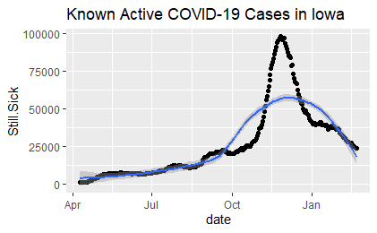

Sigh. On June 30 IDPH decided to count anyone who was still not listed as recovered after 28 days as recovered. So, let’s go back into the historic data and try to add that expectation to past recoverd data. Fortunately it is possible to download the data from the website https://coronavirus.iowa.gov/#CurrentStatus

## Percent Positive Active Cases

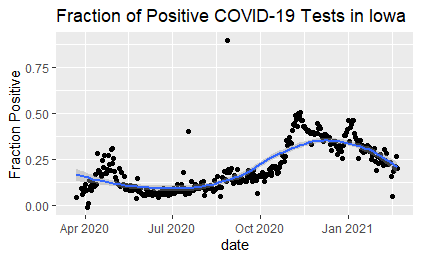

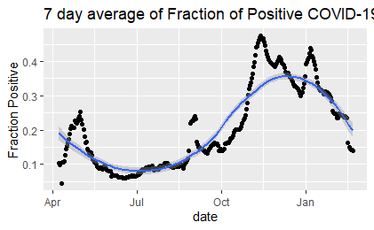

## Bremer County

I started recording daily data on Bremer county on May 29, 2020. There will be problems with the recovered data since I have yet to get tables of data for the county and the definition of recovered changed on June 30. Thus, the following graph omits that data.

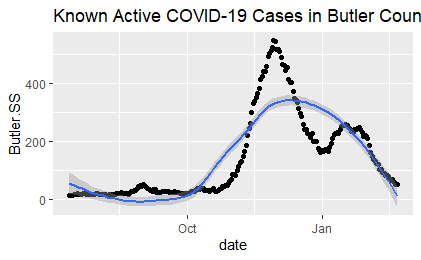

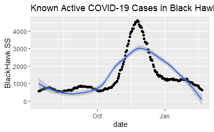

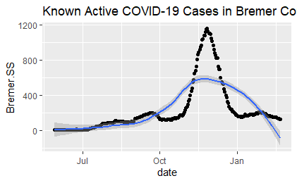

## Positive Tests

### Logistic Model

To try to fit a logistic model to the data, we want to fit a parabola to the rate of change, but the input variable is cases or deaths and not time. This is because the logistic model comes from the differential equation $\displaystyle{\frac{dP}{dt}= kP(1-\frac{P}{M})}$. Note that this equation as a function of $P$ is a parabola with zeroes at $P=0$ and $P=M$.

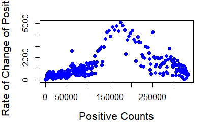

```r
clean <- clean[-c(1,10),]
with(clean, plot(positive, New.Positive, pch=16, xlab = "Positive Counts", ylab = "Rate of Change of Positive", cex.lab = 1.3, col = "blue"))
```

Now, it doesn’t really look quadratic, but we are not going to let that stop us from mathematics. Next, we will fit a quadratic model to the data.

```r
clean$P2 <- as.numeric(clean$positive)^2
quadratic <-lm(New.Positive ~ positive + P2-1, data = clean)
r <- quadratic$coefficients[2]*(-1)
M <- quadratic$coefficients[1]/r
Mprint <- format(M, scientific = FALSE)
predictedcounts <- with(clean,predict(quadratic,list(positive = positive, P2 = P2)))
```

Let’s plot the model:

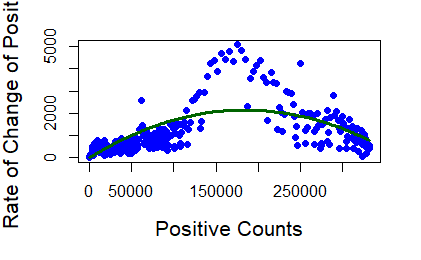

```r
with(clean, plot(positive, New.Positive, pch=16, xlab = "Positive Counts", ylab = "Rate of Change of Positive", cex.lab = 1.3, col = "blue"))
with(clean,lines(positive, predictedcounts, col = "darkgreen", lwd = 3))
```

```r
IowaPercent <- round(M/IowaPop*100, digits = 2)
```

## SIR Model

This should be more interesting and probably won’t be done for a week. The differential equations for the SIR model are:

$\frac{dS}{dt} = -r_1SI$, $\frac{dR}{dt} = r_2I$, $\frac{dI}{dt} = -\frac{dS}{dt} - \frac{dR}{dt}$

So, we may have enough data to estimate $r_1$ and $r_2$. We would do this using a linear model on the change of recovered to esitmate $r_2$ and then that model and the rate of change of infecteds to estimate $r_1$. We may have to use $M$ from the logistic growth model to estimate $S$.

### Step 1: Estimate $r_2$

```r
SIR <- with(clean, data.frame(
    dS = (-1)*diff(positive),
    dR = diff(Recovered),
    dI = diff(Still.Sick),
    dD = diff(deaths)
))
SIR <- SIR %>% mutate(
    R = clean$Recovered[-1],
    I = clean$Still.Sick[-1],
    day = clean$date[-1],
    S = M - clean$positive[-1]
    )
SIR$day = as.POSIXct(SIR$day)
SIR <- SIR[complete.cases(SIR),]
```

Let’s first just graph our data

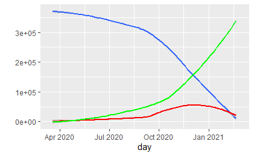

```r
qplot(day, data = SIR) +
    stat_smooth(aes( y = S),method = "loess") +
    stat_smooth( aes( y = I), color = "red", method = "loess") +
    stat_smooth( aes( y = R), color = "green", method = "loess") +
    theme(legend.position = "right")
```

(Note 5/30/2020) As of about March 15 this no longer looks like the SIR model that you would expect. We have this unexpected linear growth in $R$ where we would expect things to be more concave down at this point. Not good.

Next, let’s see about coefficients:

```r
dRmodel <- lm(dR ~ 0+I, data = SIR)
r2 <- dRmodel$coefficients[1]
dImodel <- lm (dS ~ 0 + S*I, data = SIR)
r1 <- dImodel$coefficients[1]
```

Now we plug this into the DE solver.

```r
require(deSolve)
state <- c(S = as.numeric(1-clean$positive[25]/M),
           I = as.numeric(clean$Still.Sick[25]/M),
           R = as.numeric(clean$Recovered[25]/M))
times <- seq(0, nrow(clean)-24, by = 1)
parameters <- c(r1=as.numeric(r1*M),
                r2=as.numeric(r2))

# R function to calculate the value of the derivatives at each time value
    # Use the names of the variables as defined in the vectors above
SIR <- function(time, state, parameters){
      with(as.list(c(state, parameters)), {
        dS = r1*S*I
        dR = r2*I
        dI = -r1*S*I -r2*I
        return(list(c(dS, dI, dR)))
      })
}

## Integration with 'ode'
out <- ode(y = state, times = times, func = SIR, parms = parameters, method = rk4)

    ## Ploting
    out.df = as.data.frame(out) # required by ggplot: data object must be a data frame
    require(reshape2)
    out.m = melt(out.df, id.vars='time') # this makes plotting easier by puting all variables in a single column

    p <- ggplot(out.m, aes(time, value, color = variable)) + geom_point()
    #print(p)
```

### Exponential Model

Run a linear model on the logarithm of the positive cases.

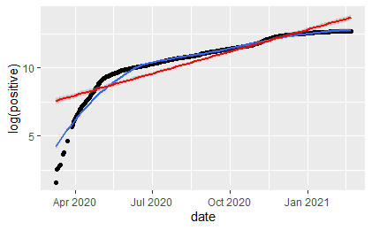

```r
qplot(date, log(positive), data =clean) + geom_point() + geom_smooth()+
  stat_smooth(method = "lm", col = "red")
```

For the model $positive = e^{k date}$, $k=$ 0.0175543. Estimated doubling time for positive cases is 39.4859204 days. Here is what that looks like on the original data.

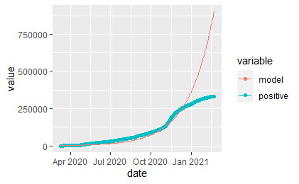

### Modified Exponential Model

By now there is strong evidence that the curve is flattening. We can create a new linear model that uses the more recent data to improve our model. Let’s look to see what happens if we only use data from later when we were doing more testing.

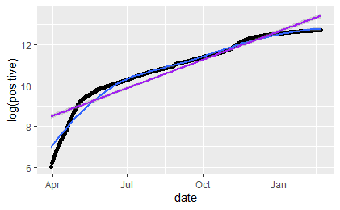

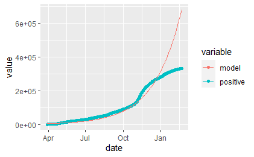

## Deaths

### Exponential Model

We will start the data when we have non-zero deaths.

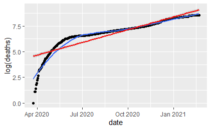

### Later Data

As above, let’s look at the same models, but only after we got serious about testing.

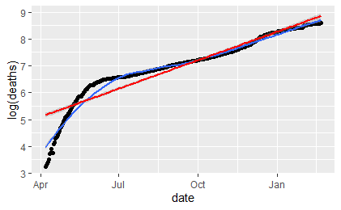

For the model $deaths = e^{k date}$, $k=$ 0.0115373. Estimated time for deaths to double is 60.0786139 days.

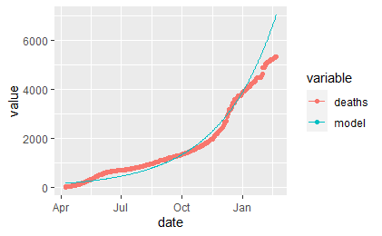

## New Positives

At the beginning, we were modeling the new positive data as an exponential curve. As of about the middle of May we changed to use the logistic growth curve from the Logistic Model to predict new positive tests.

As of about the middle of May, it becomes clear that the new positive data is not exponential. Which is really good news. This is when this model gets downgraded to the Alternative Modeling section.

# Accuracy

As with any test, there will be false positives (people who test positive, but aren’t infected) and false negatives (people who test negative, but are infected). On May 1, it was reported by the Governor’s office:

“Governor Reynolds says the State Hygienic Lab has validated the machines used as part of the Test Iowa program. “I’m pleased to announce that the State Hygienic Lab completed the Test Iowa validation process yesterday, achieving high ratings of 95% accuracy for determining positives and 99.7% accuracy for determining negatives.”"

```r
temp <- 1/(.997*.95 - (1-.995)*(1-.95))
accuracy <- clean %>%
    mutate(
    tp = .95*positive/temp,
    fp = (1-.993)/temp*positive,
    tn = 0.993/temp*negative,
    fn = (1-.95)/temp*negative) %>%
    mutate( pos = round(tp+fn, digits = 0),
            neg = round(tn+fp, digits = 0))
lastrow = length(accuracy)

# Today, the state reported `r accuracy[lastrow, 3]` total positive and `r accuracy[lastrow, 9]` total negative. Due to test inaccuracy, these numbers could be as much as `r format(accuracy[lastrow, 26], scientific = F)` positive and `r format(accuracy[lastrow, 27], scientific = F)` negative.
```

# Store Predictions

## Alternative Modeling

This didn’t turn out well, but it is still here for historical perspective:

### Positives Linear Model

First run a linear model on positive test results.

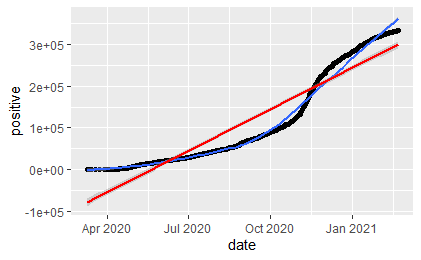

```r
qplot(date, positive, data =clean) + geom_point() + geom_smooth()+
  stat_smooth(method = "lm", col = "red")
```

### Deaths Linear Model

```
Ignoring unknown parameters: rm.na
```

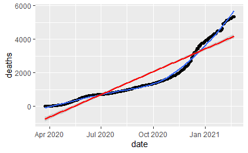

```r
qplot(date, deaths, data =cdeaths, rm.na=TRUE) + geom_point() + geom_smooth()+
  stat_smooth(method = "lm", col = "red")
```

```r
model <- lm(deaths~date, data=cdeaths)
#model$coefficients
```

## New Positives

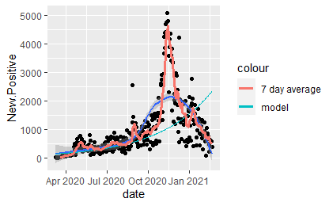

As of about the middle of May, it becomes clear that the new positive data is not exponential. Which is really good news. This is when this model gets downgraded to the Alternative Modeling section. For the model $new positives = e^{k date}$, $k=$ 0.0082678. Estimated time for new positives to double is 83.8372072 days.

```r
Summary <- pdf_text("Iowa COVID-19 Information - access.pdf") %>%
    readr::read_lines() %>% str_squish()
# temp1 = strsplit(Summary[1]," ") %>% ldply()
temp1 = Summary[6] %>% ldply()
date = as.character(mdy(temp1[1]))

Summary <- str_remove_all(Summary, " Translate") %>%
    str_remove_all("Translate")
###############################################
temp =Summary[-(22:25)]
SummaryNames = temp[seq(7,37,2)]
SummaryData = temp[seq(8,38,2)] %>%
    str_remove_all(",") %>%
    as.integer()
SummaryData = data.frame(SummaryData,
                         row.names = SummaryNames) %>%
    t()
SummaryData <- cbind("Date"=date,SummaryData)
rownames(SummaryData) = date
temp <- read.csv("SummaryData.csv",
         stringsAsFactors = FALSE) %>% as.data.frame()
# rownames(temp) = temp[,1]
colnames(SummaryData) = names(temp)
temp <- rbind(temp, SummaryData)
write.csv(temp, file = "SummaryData.csv", row.names = FALSE)
rm(temp, temp1)
```